# Sensitivity with ODEs

# Sensitivity Analysis of a differential equation

We can apply sensitivity analysis to a differential equation

A key issue where is sensitivity of what?

Dynamic models often give you many many outputs - time series (streamflow every day for a year, popultation for 30 years) - or output over space (concentration every 10 meters)

So if we are asking ‘sensitivity of what’ we need to summarize results in some way (reduce their dimensionality )

Ideas?

# Some options for reducing output dimensionality (summarizing output)

Depends on what is important for your model application

- max
- mean
- min
- total
- variation
- time it takes for something to happen

So a key step in sensitivity analysis with a dynamics model is summarizing results into a few key measures

Its useful to turn that summarizing workflow into a function

## Workflow

- obtain parameter sets (from sobel of LHS)
- build a function that will extract the information (metrics) you want from your dynamic model (output of the ode)
- create a data structure to store the metrics for each parameter set - lets call it metrics (but could be anything)
- run ODE for each parameter sets to fill in this metrics data structure
- send the metrics data structure back to the sensitivity analysis object (from sobel or LHS)
- plot and analyze results

# Example with our population ODE

```r
source("../R/dexppop_play.R")

dexppop_play
```

```
## function (time, P, parms)
## {
##     dexpop = parms$r * P
##     dexpop = ifelse(P > parms$carry_capacity, 0, dexpop)
##     return(list(dexpop))
## }
```

```r
# lets start with sobel
library(sensitivity)

# come up with first set of sample parameters
# we will assume that we know the initial population,

Pinitial=10

# want to learn about sensitivity to growth rate (r) and carrying capacity
# set the number of parameters
np=100
carry_capacity = rnorm(mean=400, sd=50, n=np)
r = rnorm(mean=0.01, sd=0.005, n=np)
X1 = cbind.data.frame(r=r, carry_capacity=carry_capacity)

# repeat to get our second set of samples
carry_capacity = rnorm(mean=400, sd=50, n=np)
r = rnorm(mean=0.02, sd=0.005, n=np)
X2 = cbind.data.frame(r=r, carry_capacity=carry_capacity)

# create our sobel object and get sets ofparameters for running the model

sens_P = sobolSalt(model = NULL,X1, X2, nboot = 300)

# our parameter sets are
head(sens_P$X)
```

```
##             [,1]     [,2]
## [1,] 0.003277916 480.0021
## [2,] 0.007705217 286.5721
## [3,] 0.015241228 317.4283
## [4,] 0.019178012 411.7796
## [5,] 0.022309012 346.3589
## [6,] 0.007592260 334.2809
```

```r
# lets add names
colnames(sens_P$X) = c("r","carry_capacity")

# run our differential equation and keep the output
# BUT
# what output do we want  to keep
# how about maximum population if we run the model for 200 years, and how many years to get to the carrying capacity

# for illustration lets look at running just one parameter sets and summarizing results
sens_P$X[1,]
```

```
##              r carry_capacity
##   3.277916e-03   4.800021e+02
```

```r
# recall ODE needs ALL of our parameters in a single list
# initial population and timnes for which we want output
Pinitial
```

```
## [1] 10
```

```r
# gets results for 200 years (evaluating every year)
simtimes = seq(from=1, to=200)
parms = list(r=sens_P$X[1,"r"], carry_capacity=sens_P$X[1,"carry_capacity"])

# or
parms = list(r=as.data.frame(sens_P$X)$r[1], carry_capacity=as.data.frame(sens_P$X)$carry_capacity[1])

result = ode(y=Pinitial, times=simtimes, func=dexppop_play, parms=parms)

head(result)
```

```
##      time        1
## [1,]    1 10.00000
## [2,]    2 10.03283
## [3,]    3 10.06577
## [4,]    4 10.09882
## [5,]    5 10.13198
## [6,]    6 10.16525
```

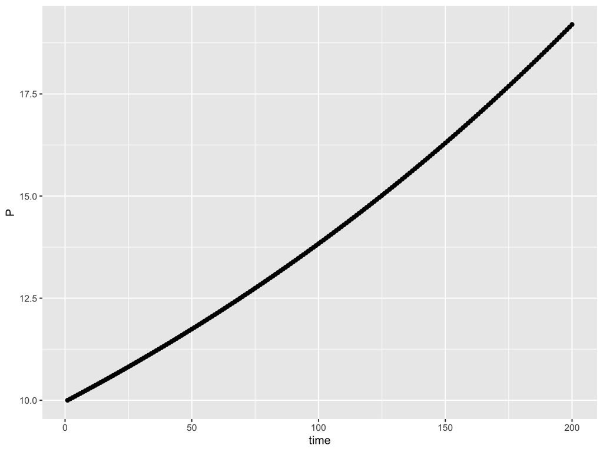

```r
colnames(result)=c("time","P")
# turn it into a data frame
result = as.data.frame(result)
ggplot(result, aes(time, P))+geom_point()
```

```r
# extra our metrics of interest  from this
# maximum population it gets to
maxpop = max(result$P)
maxpop
```

```
## [1] 19.19962
```

```r
# years required to get to the maximum poputation
# which.max will tell us when max population occur
idx = which.max(result$P)
# turn this index into a year (might be the same if time step in 1 but just in case it isn't)
maxyear = result$time[idx]
maxyear
```

```
## [1] 200
```

# Compute our metric for all the parameter sets

What if we want to run for all parameters

Lets create two additional functions that will help us

- a function that computes the metrics we want
- a function that runs our ode solver and computes the metrics (I call it a wrapper function as it is really just a workflow/wrapper to call ode solver and then compute metrics)

```r
# turn computing our metrics into a function

compute_metrics = function(result) {
  maxpop = max(result$P)
idx = which.max(result$P)
maxyear = result$time[idx]
return(list(maxpop=maxpop, maxyear=maxyear))}

# try it on our first parameter set
compute_metrics(result)
```

```
## $maxpop
## [1] 19.19962
##
## $maxyear
## [1] 200
```

```r
# great but we need to apply the ode and this function for all of our parameters



# define a wrapper function to do everything we need - run solver and compute metrics - and send back results for each parameter

p_wrapper = function(r,carry_capacity, Pinitial, simtimes, func) {
    parms = list(r=r, carry_capacity=carry_capacity)
    result = ode(y=Pinitial, times=simtimes, func=func, parms=parms)
    colnames(result)=c("time","P")
  # get metrics
  metrics=compute_metrics(as.data.frame(result))
  return(metrics)
}

# now use pmap as we did before

allresults = as.data.frame(sens_P$X) %>% pmap(p_wrapper, Pinitial=Pinitial, simtimes=simtimes, func=dexppop_play)
```

[output not shown]

[output not shown]

[output not shown]

[output not shown]

[output not shown]

[output not shown]

[output not shown]

[output not shown]

[output not shown]

[output not shown]

[output not shown]

[output not shown]

[output not shown]

[output not shown]

[output not shown]

[output not shown]

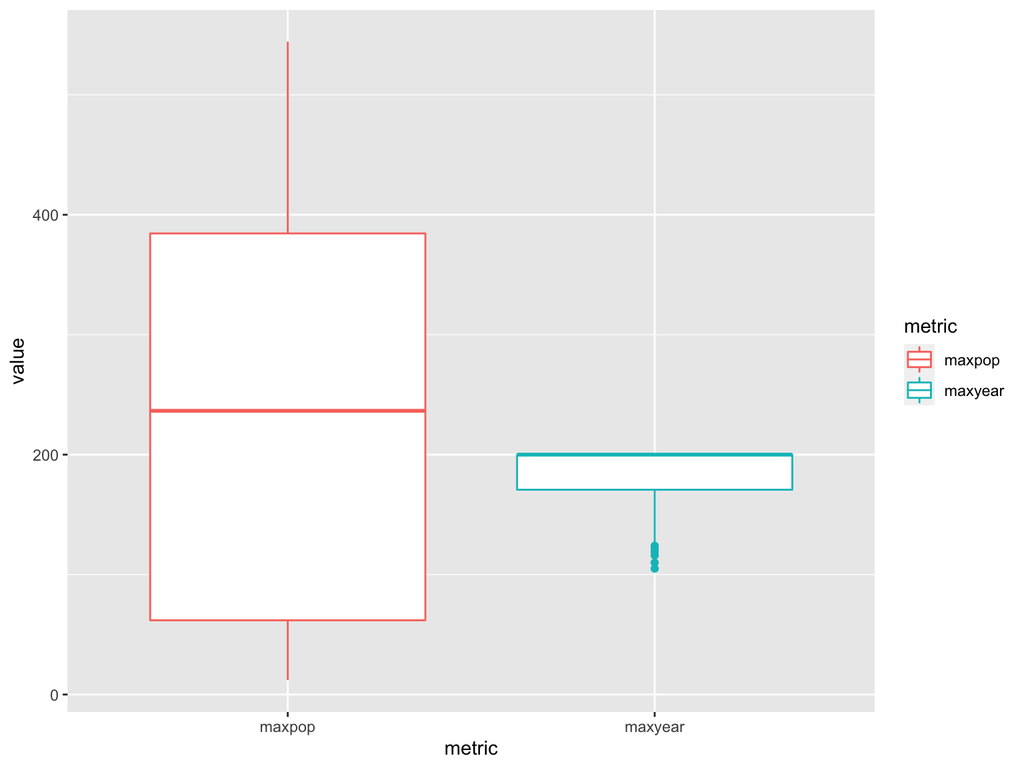

```r
# extract out results from pmap into a data frame
allres = allresults %>% map_dfr(`[`,c("maxpop","maxyear"))


# create boxplots
tmp = allres %>% gather(key="metric", value="value")
ggplot(tmp, aes(metric, value, col=metric))+geom_boxplot()
```

Compute the sobol indicies for each metric

```r
# sobol can only handle one output at a time  - so we will need to do them separately

sens_P_maxpop = sensitivity::tell(sens_P,allres$maxpop)

# first-order indices (main effect without co-variance)
sens_P_maxpop$S
```

```
##      original          bias  std. error  min. c.i.  max. c.i.
## X1  0.9945726  0.0002646962 0.003626273  0.9892009  1.0024568
## X2 -0.5288707 -0.0020421208 0.077380382 -0.6930871 -0.3819963
```

```r
# total sensitivity index -note that this partitions the output variance - so values sum to 1
sens_P_maxpop$T
```

```
##     original        bias std. error min. c.i. max. c.i.
## X1 1.5046810 0.001106349 0.08725647 1.3452648  1.686847
## X2 0.1876252 0.005574883 0.04792026 0.0613934  0.254028
```

```r
# create another one for max year
sens_P_maxyear = sensitivity::tell(sens_P,allres$maxyear)
# first-order indices (main effect without co-variance)
sens_P_maxyear$S
```

```
##      original         bias std. error  min. c.i.  max. c.i.
## X1  0.9609562 -0.043834158 0.13898518  0.9246011  1.4762764
## X2 -0.3684145 -0.001354882 0.05722078 -0.4860903 -0.2683889
```

```r
# total sensitivity index -note that this partitions the output variance - so values sum to 1
sens_P_maxyear$T
```

```
##      original         bias std. error  min. c.i.  max. c.i.
## X1 1.37249895 0.0005541132 0.05280874 1.28060278 1.48234254
## X2 0.03990512 0.0007424527 0.00730839 0.02334924 0.05140491
```

# Error messages from ODE

*In lsoda(y, times, func, parms, …) : an excessive amount of work (> maxsteps ) was done, but integration was not successful - increase maxsteps*

Suggest that the solver (numerical integration) had issues

- increasing maxsteps can help

  ```
  *result = ode(y=Pinitial, times=simtimes, func=func, parms=parms, maxsteps=100000) *
  ```

- trying different methods

  ```
  *result = ode(y=Pinitial, times=simtimes, func=func, parms=parms, method="daspk")*
  ```

- “stiff” problems are harder for numerical integration to solve - (small changes have big impacts); our threshold carrying capacity does that - change to make is a more smooth transition

  thoughts on how to do this?

# For next class (not to hand in - just practice on your own)

Go through in-class examples;

- try varying parameter ranges,
- try changing the population growth function to smooth the transition to no growth when a carrying capacity is approached ;
- try developing a different metric

We will go over this in class on Tuesday

Want to go further?….

Try using Sobol for the diffusion model - what would be your metric?